# Lab 4 Modeling With Rasters

## Question 5

1. predict your best glm from question 4 to create a raster of your model. b) Plot your model to cropped to the boundary layer, c) with a color ramp of 10 color increments.

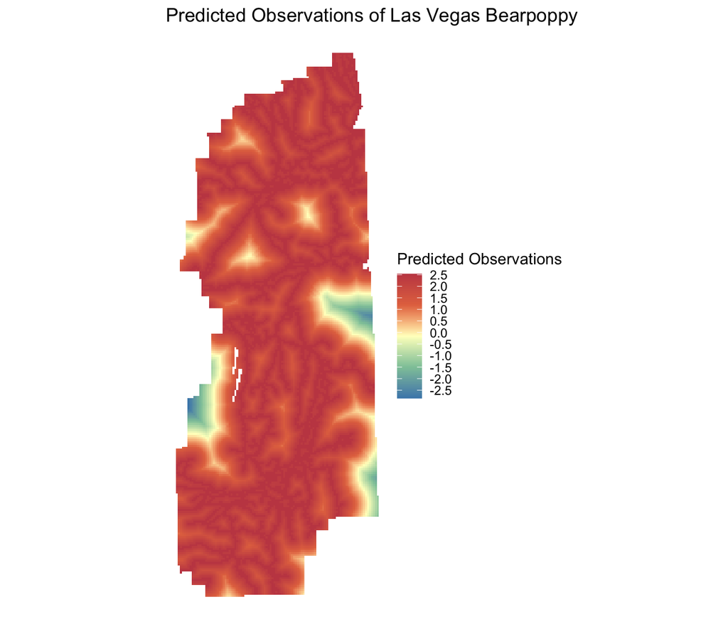

```r
ObsRaster <- predict(D2Rds_crop, LVB_logNobs_glm)
# plot(ObsRaster)
## changing name
LogBearpoppy_plot <- ggplot() +
  theme_void() +
  ggtitle("Predicted Observations of Las Vegas Bearpoppy") +
  geom_spatraster(data = ObsRaster) +
  scale_fill_whitebox_c(palette = "muted", n = 10, name = "Predicted Observations", na.value = "white")
LogBearpoppy_plot
```

## Question 6 616 Yes, 416 XC

Read the paper by Van Linn et al. 2016. What was being modeled by these researchers? How did the authors reduce the spatial bias in the data due to the limited locations in which fire occurred? How did the authors validate their model?

Answer: The researchers are modeling fuel loads first, then using their fuel loads model in addition to other sources of input data to model fire risk. The authors attempted to reduce spatial bias in the data by using 2005 as a base year for the fire risk model, since using other years would potentially lead to a fire risk model that underestimated the potential of fire occurrence. The researchers also attempted to reduce spatial bias in the data by randomly selecting 5000 cells in order to avoid overfitting. This way they could ensure they were modelling fire risk as accurately as possible throughout the whole study area, rather than just creating a map which matched fire occurrence in 2005 but was not useful for any other years. The authors validated their fire risk model by applying the fire risk model to a different area not part of the main study site that had similar environmental characteristics in order to evaluate model performance and ensure the model was not overly specific to just the Gold Butte study area.